# Guided tour of species distribution modeling: Blanding's turtle

## 4. Define study area and extent of possible range

Select the study area, e.g. (if your species is terrestrial) using the countries where your species has occurrence points (which means it was surveyed in those countries)

Mind there are several other ways of delimiting the study area, e.g. using ecoregions or other biogeographic units)

First, convert the species occurrences to a spatial object (like when you import a delimited text file into a GIS, you need to specify which columns contain the spatial coordinates and what is the cartographic projection / coordinate reference system):

```r
names(presences)
```

```
## [1] "key"                           "decimalLongitude"
## [3] "decimalLatitude"               "coordinateUncertaintyInMeters"
## [5] "uniqueID"
```

```r
pres_spat_vect <- vect(presences,
                     geom = c("decimalLongitude", "decimalLatitude"),
                     crs = "+proj=longlat")
```

Then get the country polygons that contain presence points:

```r
pres_countries <- countries[pres_spat_vect, ]
plot(pres_countries)
```

```
## Error in as.double(y): cannot coerce type 'S4' to vector of type 'double'
```

```r
plot(pres_spat_vect, col = "blue", add = TRUE)
```

```
## Error in as.double(y): cannot coerce type 'S4' to vector of type 'double'
```

```r
# if your species is terrestrial and you see that in some countries it is clearly under-surveyed, you can select only particular countries where the survey was better distributed, for example:
#names(pres_countries)
#unique(pres_countries$NAME)
#chosen_countries <- subset(pres_countries, pres_countries$NAME %in% c("United States of America", "Canada" ))
#plot(chosen_countries)
```

Then also buffer your points with reasonable distance

```r
pres_buff <- terra::aggregate(terra::buffer(pres_spat_vect, width = 50000))
plot(pres_buff, lwd = 2)
```

```
## Error in as.double(y): cannot coerce type 'S4' to vector of type 'double'
```

```r
plot(pres_spat_vect, col = "blue", add = TRUE)
```

```
## Error in as.double(y): cannot coerce type 'S4' to vector of type 'double'
```

```r
plot(countries, border = "tan", add = TRUE)
```

```
## Error in as.double(y): cannot coerce type 'S4' to vector of type 'double'
```

Finally, define study area as the area within buffer but also within countries (e.g., not ocean)

```r
studyarea <- intersect(pres_buff, countries)
plot(studyarea, border = "red", lwd = 3, add = TRUE)
```

```
## Error in xy.coords(x, y, xlabel, ylabel, log): 'x' is a list, but does not have components 'x' and 'y'
```

```r
studyarea <- as(studyarea, "Spatial")
```

```
## Error in as(studyarea, "Spatial"): no method or default for coercing "list" to "Spatial"
```

```r
# IF YOU USED A LIMITED WINDOW OF COORDINATES to download the occurrence data,
# you need to intersect or crop with that too:
#studyarea <- intersect(studyarea, mywindow)
#plot(studyarea, border = "green", add = TRUE)
```

Cut the variable maps with the limits of the study area:

```r
layers_cut <- terra::crop(terra::mask(layers, studyarea), studyarea)
```

```
## Error in h(simpleError(msg, call)): error in evaluating the argument 'x' in selecting a method for function 'crop': unable to find an inherited method for function 'mask' for signature '"RasterStack", "list"'
```

```r
plot(layers_cut[[1]])
```

```
## Error in as.double(y): cannot coerce type 'S4' to vector of type 'double'
```

Remember, the spatial resolution of the variables should be adequate to the data and study area!

Closely inspect your species data vs. the size of the variables' pixels:

```r
plot(layers_cut[[1]])
```

```
## Error in as.double(y): cannot coerce type 'S4' to vector of type 'double'
```

```r
plot(pres_spat_vect, col = "blue", cex = 0.1, add = TRUE)
```

```
## Error in as.double(y): cannot coerce type 'S4' to vector of type 'double'
```

```r
# plot within smaller x/y limits if necessary to see if presence point
# resolution matches pixel resolution:
#plot(layers_cut[[1]], xlim = c(-84.5, -81.5), ylim = c(41, 44))
#plot(pres_spat_vect, col = "blue", add = TRUE)

# IF NECESSARY, you can aggregate the layers, to e.g. a 5-times coarser resolution (choose the 'fact' value that best matches your presence data resolution to your variables' resolution):
# layers_aggr <- terra::aggregate(layers_cut, fact = 5, fun = mean)
# res(layers_aggr)
# plot(layers_aggr[[1]], xlim = range(presences$decimalLongitude), ylim = range(presences$decimalLatitude))
# plot(pres_spatial, col = "blue", cex = 0.1, add = TRUE)

# run the command below only if you did need to aggregate the layers:
#layers_cut <- layers_aggr
```

Have to add in non-presence data

```r
dat <- fuzzySim::gridRecords(rst = layers_cut,
                   pres.coords = presences[ , c("decimalLongitude", "decimalLatitude")])
head(dat)
```

```
##   presence         x          y  cells WC_alt WC_bio1 WC_bio2 WC_bio4 WC_bio6
## 4        1 -59.12500   4.208333  94368    289    25.9     8.9    5.36    20.7
## 5        1 -79.79167  -3.458333 156772    501    23.7     9.9    5.31    18.1
## 6        1 -60.04167  -3.125000 154285     25    27.5     8.3    4.47    22.9
## 7        1 -44.29167 -20.208333 294079    839    20.9    13.0   19.33     9.9
## 8        1 -83.70833   8.625000  57980    114    25.9    11.1    7.58    19.1
## 9        1 -80.62500   8.875000  55974    117    26.4     7.7    6.94    21.8
##   WC_bio7 WC_bio12 WC_bio13 WC_bio17 WC_prec3 WC_prec4 WC_prec10 WC_prec11
## 4    11.1     1763      346      183       89      149        46        56
## 5    11.6     1050      199       63      192      149        31        36
## 6    10.1     2159      296      212      296      284       125       166
## 7    19.3     1362      292       33      149       57       123       235
## 8    14.4     4654      786      263      127      210       786       580
## 9    10.1     3290      390      351       80      231       379       362
##   WC_tmax3 WC_tmax4 WC_tmax10 WC_tmean4 WC_tmin4 WC_tmin10 WC_tmin11
## 4     30.3     30.4      31.8      25.9     21.5      22.1      21.8
## 5     29.4     29.7      28.0      24.6     19.6      18.5      18.4
## 6     30.9     31.0      32.3      27.2     23.4      23.8      23.6
## 7     28.3     26.8      28.2      20.2     13.7      16.3      17.0
## 8     33.5     33.3      30.0      27.3     21.4      20.4      20.0
## 9     31.8     31.9      29.3      27.7     23.5      21.9      22.1
```

```r
table(dat$presence)
```

```
##
##     0     1
## 14146   277
```

Map these data

```r
plot(layers_cut[[1]], xlim = c(-90, -35), ylim = c(-30, 15))
```

```
## Error in as.double(y): cannot coerce type 'S4' to vector of type 'double'
```

```r
# plot the absences (pixels without presence records):
points(dat[dat$presence == 0, c("x", "y")], col = "red", cex = 0.5)
```

```
## Error in plot.xy(xy.coords(x, y), type = type, ...): plot.new has not been called yet
```

```r
# plot the presences (pixels with presence records):
points(dat[dat$presence == 1, c("x", "y")], col = "blue", cex = 0.7)
```

```
## Error in plot.xy(xy.coords(x, y), type = type, ...): plot.new has not been called yet
```

Now, convert back to a spatial data frame

```r
dat_spat <- SpatialPointsDataFrame(coords = dat[,c("x", "y")],
                                   data = dat,
                                   proj4string = crs("+proj=longlat"))
```

Finally, make a dataframe (which you'll need for modelling) of the species occurrence data gridded (thinned) to the resolution of the raster variables  
(i.e., one row per pixel with the values of the variables and the presence/absence of the species):

```r
df.sdm <- sdm::sdmData(formula = presence ~ .,
                       train = dat_spat,
                  predictors = layers_cut[[1:2]])
df.sdm
```

```
## class                                 : sdmdata
## ===========================================================
## number of species                     :  1
## species names                         :  presence
## number of features                    :  23
## feature names                         :  cells, WC_bio2, WC_bio4, ...
## type                                  :  Presence-Absence
## has independet test data?             :  FALSE
## number of records                     :  14423
## has Coordinates?                      :  TRUE
```

## 5. Run models and create a predicted distribution map

```r
m1 <- sdm(presence ~ WC_bio12 + WC_bio1 + I(WC_bio1^2),
          data = df.sdm,
          methods = c("glm"))
m1
```

```
## class                                 : sdmModels
## ========================================================
## number of species                     :  1
## number of modelling methods           :  1
## names of modelling methods            :  glm
## ------------------------------------------
## model run success percentage (per species)  :
## ------------------------------------------
## method          presence
## ----------------------
## glm        :        100   %
##
## ###################################################################
## model performance (per species), using training test dataset:
## -------------------------------------------------------------------------------
##
##  ## species   :  presence
## =========================
##
## methods    :     AUC     |     COR     |     TSS     |     Deviance
## -------------------------------------------------------------------------
## glm        :     0.62    |     0.05    |     0.19    |     0.19
```

Prediction map

```r
p1 <- predict(m1, newdata = layers_cut,
              filename= 'NGruwell/output/figures/p1.img',
              overwrite=T)
plot(studyarea, border = "red", lwd = 3)
```

```
## Error in xy.coords(x, y, xlabel, ylabel, log): 'x' is a list, but does not have components 'x' and 'y'
```

```r
plot(countries, border = "tan", add = T)
```

```
## Error in as.double(y): cannot coerce type 'S4' to vector of type 'double'
```

```r
plot(p1, add = T)
```

```
## Error in as.double(y): cannot coerce type 'S4' to vector of type 'double'
```

Variable importance

```r
vi <- getVarImp(m1)
```

```
##
## The values of relative variable importance are generated from 1 models...
```

```r
vi
```

```
## Relative Variable Importance
## =============================================================
## method              : Permutation based on two metrics (Pearson Correlation and AUC)
## number of variables :  3
## variable names      :  WC_bio12, WC_bio1, WC_bio1.quad
## =============================================================
## Relative variable importance
## ----------------------------------------------
## Based on Correlation metric:
## ----------------------------------------------
## WC_bio12            : ******************************************* (86.4 %)
## WC_bio1             : ************************************************** (100 %)
## WC_bio1.quad        : ************************************* (73.7 %)
## =============================================================
## Based on AUC metric:
## ----------------------------------------------
## WC_bio12            : ********* (17.9 %)
## WC_bio1             : *********** (21.5 %)
## WC_bio1.quad        : ****** (12.6 %)
## =============================================================
```

```r
plot(vi)
```

```
## Error in as.double(y): cannot coerce type 'S4' to vector of type 'double'
```

View Coefficients

```r
plogis(getModelObject(m1)[[1]]) # transforming out of logit scale to more
```

```
##  (Intercept)     WC_bio12      WC_bio1 WC_bio1.quad
## 0.0007243411 0.5000906068 0.5564987157 0.4987225350
```

```r
# sensical scales
```

Variable selection?

```r
m2.select <- sdm(presence ~ WC_bio12 + WC_bio1 + I(WC_bio1^2),
                 data = df.sdm, methods = c("glm"), var.selection = T)
getModelObject(m2.select)[[1]]
```

```
##  (Intercept)     WC_bio12      WC_bio1 WC_bio1.quad
## -7.229523501  0.000362427  0.226964165 -0.005109871
```

```r
getVarImp(m2.select)
```

```
##
## The values of relative variable importance are generated from 1 models...
```

```
## Relative Variable Importance
## =============================================================
## method              : Permutation based on two metrics (Pearson Correlation and AUC)
## number of variables :  3
## variable names      :  WC_bio12, WC_bio1, WC_bio1.quad
## =============================================================
## Relative variable importance
## ----------------------------------------------
## Based on Correlation metric:
## ----------------------------------------------
## WC_bio12            : ******************************************* (86.9 %)
## WC_bio1             : ************************************************** (100 %)
## WC_bio1.quad        : ************************************* (74.1 %)
## =============================================================
## Based on AUC metric:
## ----------------------------------------------
## WC_bio12            : ********** (19.9 %)
## WC_bio1             : *********** (21.3 %)
## WC_bio1.quad        : ****** (11.2 %)
## =============================================================
```

```r
plot(getVarImp(m2.select))
```

```
##
## The values of relative variable importance are generated from 1 models...
```

```
## Error in as.double(y): cannot coerce type 'S4' to vector of type 'double'
```

```r
m2.select
```

```
## class                                 : sdmModels
## ========================================================
## number of species                     :  1
## number of modelling methods           :  1
## names of modelling methods            :  glm
## ------------------------------------------
## model run success percentage (per species)  :
## ------------------------------------------
## method          presence
## ----------------------
## glm        :        100   %
##
## ###################################################################
## model performance (per species), using training test dataset:
## -------------------------------------------------------------------------------
##
##  ## species   :  presence
## =========================
##
## methods    :     AUC     |     COR     |     TSS     |     Deviance
## -------------------------------------------------------------------------
## glm        :     0.62    |     0.05    |     0.19    |     0.19
```

```r
m2.noaltquad <- sdm(presence ~ WC_alt + WC_bio1 + I(WC_bio1^2),
                 data = df.sdm, methods = c("glm"), var.selection = F)
m2.noaltquad
```

```
## class                                 : sdmModels
## ========================================================
## number of species                     :  1
## number of modelling methods           :  1
## names of modelling methods            :  glm
## ------------------------------------------
## model run success percentage (per species)  :
## ------------------------------------------
## method          presence
## ----------------------
## glm        :        100   %
##
## ###################################################################
## model performance (per species), using training test dataset:
## -------------------------------------------------------------------------------
##
##  ## species   :  presence
## =========================
##
## methods    :     AUC     |     COR     |     TSS     |     Deviance
## -------------------------------------------------------------------------
## glm        :     0.56    |     0.03    |     0.13    |     0.19
```

```r
getVarImp(m2.noaltquad)
```

```
##
## The values of relative variable importance are generated from 1 models...
```

```
## Relative Variable Importance
## =============================================================
## method              : Permutation based on two metrics (Pearson Correlation and AUC)
## number of variables :  3
## variable names      :  WC_alt, WC_bio1, WC_bio1.quad
## =============================================================
## Relative variable importance
## ----------------------------------------------
## Based on Correlation metric:
## ----------------------------------------------
## WC_alt              : ***** (10 %)
## WC_bio1             : ************************************************** (100 %)
## WC_bio1.quad        : **************************************** (80.7 %)
## =============================================================
## Based on AUC metric:
## ----------------------------------------------
## WC_alt              : * (2.7 %)
## WC_bio1             : ********* (17.8 %)
## WC_bio1.quad        : **** (7.2 %)
## =============================================================
```

Cross-validation

```r
m3.cv <- sdm(presence ~ WC_bio12 + WC_bio1 + I(WC_bio1^2),
             data = df.sdm, methods = c("glm"),
             replication = "cv", cv.folds = 4, n = 5) # n = 5 for your assignment
m3.cv
```

```
## class                                 : sdmModels
## ========================================================
## number of species                     :  1
## number of modelling methods           :  1
## names of modelling methods            :  glm
## replicate.methods (data partitioning) :  cross_validation
## number of replicates (each method)    :  5
## toral number of replicates per model  :  20 (per species)
## ------------------------------------------
## model run success percentage (per species)  :
## ------------------------------------------
## method          presence
## ----------------------
## glm        :        100   %
##
## ###################################################################
## model Mean performance (per species), using test dataset (generated using partitioning):
## -------------------------------------------------------------------------------
##
##  ## species   :  presence
## =========================
##
## methods    :     AUC     |     COR     |     TSS     |     Deviance
## -------------------------------------------------------------------------
## glm        :     0.61    |     0.05    |     0.21    |     0.19
```

```r
plogis(getModelObject(m3.cv, id = 1)[[1]])
```

```
##  (Intercept)     WC_bio12      WC_bio1 WC_bio1.quad
## 0.0002713302 0.5000773121 0.5788947347 0.4982613249
```

```r
getVarImp(m3.cv)
```

```
##
## The variable importance for all the models are combined (averaged)...
```

```
## Relative Variable Importance List
## =============================================================
## method              : Permutation based on two metrics (Pearson Correlation and AUC)
## number of variables :  3
## variable names      :  WC_bio12, WC_bio1, WC_bio1.quad
## number of models    :  20
## =============================================================
## Summary of relative variable importance
## ----------------------------------------------
## Based on Correlation metric:
## ----------------------------------------------
## WC_bio12            : **************************************[****--] (85.2 %)
## WC_bio1             : ****************************************[*******------] (95.1 %)
## WC_bio1.quad        : *************************[*********-------] (69.6 %)
## =============================================================
## Based on AUC metric:
## ----------------------------------------------
## WC_bio12            : ******[***--] (19.6 %)
## WC_bio1             : ******[****--] (21.2 %)
## WC_bio1.quad        : **[***-] (11.3 %)
## =============================================================
```

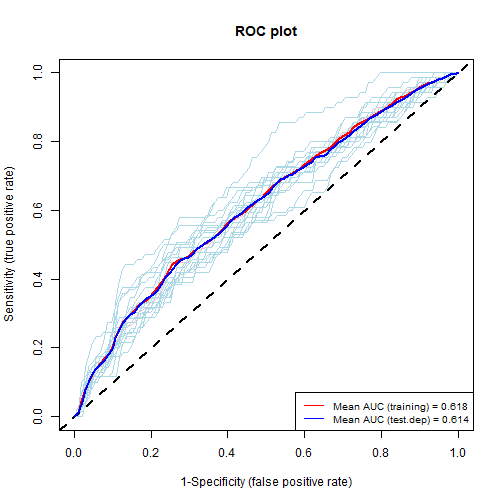

```r
roc(m3.cv)
```

### Footer

spin this with: ezspin(file = “NGruwell/programs/20220413_example_SDM_adv.R”,out_dir = “NGruwell/output”, fig_dir = “figures”,keep_md = FALSE, keep_rmd = FALSE)